# Write a Data Science Blog Post @Udacity - Become a Data Scientist

by Armin Sedlmeyr, a Udacity student from Munich, Germany working @BMW Group

## General Project Requirements:

> **Code Functionality and Readability**:
> - [x] Code has easy-to-follow logical structure. The code uses comments effectively and/or Notebook Markdown cells correctly. The steps of the data science process (gather, assess, clean, analyze, model, visualize) are clearly identified with comments or Markdown cells, as well. The naming for variables and functions should be according to PEP8 style guide.
> - [x] All the project code is contained in a Jupyter notebook, which demonstrates successful execution and output of the code.
> - [x] Code is well documented and uses functions and classes as necessary. All functions include document strings. DRY principles are implemented.

> **Data**:
> - [x] Project follows the CRISP-DM process outlined for questions through communication. This can be done in the README or the notebook. If a question does not require machine learning, descriptive or inferential statistics should be used to create a compelling answer to a particular question.
> - [x] Categorical variables are handled appropriately for machine learning models (if models are created). Missing values are also handled appropriately for both descriptive and ML techniques. Document why a particular approach was used, and why it was appropriate for a particular situation.

> **Analysis, Modeling, Visualization**:
> - [x] There are between 3-5 questions asked, related to the business or real-world context of the data. Each question is answered with an appropriate visualization, table, or statistic.

> **Github Repository**:
> - [x] Student must have a Github repository of their project. The repository must have a README.md file that communicates the libraries used, the motivation for the project, the files in the repository with a small description of each, a summary of the results of the analysis, and necessary acknowledgements. Students should not use another student's code to complete the project, but they may use other references on the web including StackOverflow and Kaggle to complete the project.

> **Blog Post**:
> - [x] Student must have a blog post on a platform of their own choice (can be on their website, a Medium post or Github blog post). Student must communicate their results clearly. The post should not dive into technical details or difficulties of the analysis - this should be saved for Github. The post should be understandable for non-technical people from many fields.
> - [x] Student must have a title and image to draw readers to their post.
> - [x] There are no long, ongoing blocks of text without line breaks or images for separation anywhere in the post.
> - [x] Each question is answered with a clear visual, table, or statistic that provides how the data supports or disagrees with some hypothesis that could be formed by each question of interest.

# Introduction

#### Data Set Information

**Airbnb Open Data.** Since 2008, guests and hosts have used Airbnb to travel in a more unique, personalized way. As part of the Airbnb Inside initiative, this dataset describes the listing activity of homestays in Seattle, WA/in Boston, MA.

Listings, including full descriptions and average review score

Reviews, including unique id for each reviewer and detailed comments

Calendar, including listing id and the price and availability for that day

#### Data used

- kaggle-seattle-air-bnb [link](https://www.kaggle.com/airbnb/seattle)
- kaggle-boston-air-bnb [link](https://www.kaggle.com/airbnb/boston)

## Crisp-DM Step 1 - Business Understanding

#### Inspiration by https://www.kaggle.com/airbnb/seattle/ & https://www.kaggle.com/arjunpmm/airbnb-seattle-analysis-and-prediction

- Can you describe the vibe of each Seattle neighborhood using listing descriptions?
- What are the busiest times of the year to visit Seattle? By how much do prices spike?
- Is there a general upward trend of both new Airbnb listings and total Airbnb visitors to Seattle?

#### Own ideas:

- What influences the price?
- What influences the review score?
- Does the weekday influence the price of a listing?
- Does the season/month influence the price of a listing?

## 1. Data Wrangling

## 1.1 Gather

```python
#import libararies needed
import warnings
warnings.filterwarnings('ignore')
from wordcloud import WordCloud, STOPWORDS
from nltk.corpus import stopwords
import string
import nltk
#nltk.download('punkt')
#nltk.download('stopwords')
#nltk.download('averaged_perceptron_tagger')
import pandas as pd
from langdetect import detect
import matplotlib.pyplot as plt
import numpy as np
from sklearn.feature_selection import RFE
import timeit
from IPython.display import display
import matplotlib.pyplot as plt
from sklearn.svm import SVR
from sklearn.linear_model import LinearRegression
from sklearn.linear_model import Lasso
from sklearn.linear_model import ElasticNet
from sklearn.linear_model import Ridge
from sklearn.linear_model import HuberRegressor
from sklearn.model_selection import train_test_split
from sklearn.metrics import r2_score, mean_squared_error
import seaborn as sns

#notebook config
pd.set_option('display.max_colwidth', -1)
pd.options.display.max_columns = None

#load the csv-file into a dataframe from the jupyter workspace
boston_calendar = pd.read_csv('boston-calendar.csv')
boston_listings = pd.read_csv('boston-listings.csv')
boston_reviews = pd.read_csv('boston-reviews.csv')
seattle_calendar = pd.read_csv('seattle-calendar.csv')
seattle_listings = pd.read_csv('seattle-listings.csv')
seattle_reviews = pd.read_csv('seattle-reviews.csv')
```

## 1.2 Assess (Crisp-DM-Step 2 - Data Understanding)

> **General Notes about this step of Data Wrangling**:
> - **Types of assessment**:
>   - Visual assessment: scrolling through the data in your preferred software application (Google Sheets, Excel, a text editor, etc.).
>     - df.head()
>     - df.tail()
>     - df
>     - df.sample()
>   - Programmatic assessment: using code to view specific portions and summaries of the data (pandas' head, tail, and info methods, for example).
>     - df.duplicated()
>     - .head (DataFrame and Series)
>     - .tail (DataFrame and Series)
>     - .sample (DataFrame and Series)
>     - .info (DataFrame only)
>     - .describe (DataFrame and Series)
>     - .value_counts (Series only)
>     - all_columns = pd.Series(list(df1)) + pd.Series(list(df2)) + pd.Series(list(df3)) #find out duplicate columns between datasets
>     - all_columns[all_columns.duplicated()] #find out duplicate columns between datasets
>     - Various methods of indexing and selecting data (.loc and bracket notation with/without boolean indexing, also .iloc)!
> - **Quality**
>   - Dirty data = low quality data = content issues
>   - Quality dimensions:
>     - *Completeness*: do we have all of the records that we should? Do we have missing records or not? Are there specific rows, columns, or cells missing?
>     - *Validity*: we have the records, but they're not valid, i.e., they don't conform to a defined schema. A schema is a defined set of rules for data. These rules can be real-world constraints (e.g. negative height is impossible) and table-specific constraints (e.g. unique key constraints in tables).
>     - *Accuracy*: inaccurate data is wrong data that is valid (meaning is being technically possible, e.g. a height, that is way to low, but still is valid in the dataset, or someone named "Dsvid", that is not illegal, e.g. technically possible, but not probable). It adheres to the defined schema, but it is still incorrect. Example: a patient's weight that is 5 lbs too heavy because the scale was faulty.
>     - *Consistency*: inconsistent data is both valid and accurate, but there are multiple correct ways of referring to the same thing. Consistency, i.e., a standard format, in columns that represent the same data across tables and/or within tables is desired. (e.g. an abbreviated country, and in the same table the country being written out)!
>   - Sources of dirty data:
>     - We're going to have user entry errors.
>     - In some situations, we won't have any data coding standards, or where we do have standards they'll be poorly applied, causing problems in the resulting data
>     - We might have to integrate data where different schemas have been used for the same type of item.
>     - We'll have legacy data systems, where data wasn't coded when disc and memory constraints were much more restrictive than they are now. Over time systems evolve. Needs change, and data changes.
>     - Some of our data won't have the unique identifiers it should.
>     - Other data will be lost in transformation from one format to another.
>     - And then, of course, there's always programmer error.
>     - And finally, data might have been corrupted in transmission or storage by cosmic rays or other physical phenomenon. So hey, one that's not our fault.!
> - **[Tidiness](https://cran.r-project.org/web/packages/tidyr/vignettes/tidy-data.html)**
>   - Messy data = untidy data = structural issues!
>   - Tidy data requirement:
>     - Each variable forms a column.
>     - Each observation forms a row.
>     - Each type of observational unit forms a table.
>   - This section describes the five most common problems with messy datasets, along with their remedies:
>     - Column headers are values, not variable names.
>     - Multiple variables are stored in one column.
>     - Variables are stored in both rows and columns.
>     - Multiple types of observational units are stored in the same table.
>     - A single observational unit is stored in multiple tables.

```python
#visual assessement
boston_calendar.head()
```

|  | listing_id | date | available | price |
| --- | --- | --- | --- | --- |
| 0 | 12147973 | 2017-09-05 | f | NaN |
| 1 | 12147973 | 2017-09-04 | f | NaN |
| 2 | 12147973 | 2017-09-03 | f | NaN |
| 3 | 12147973 | 2017-09-02 | f | NaN |
| 4 | 12147973 | 2017-09-01 | f | NaN |

```python
boston_calendar.available.value_counts()
```

```
f    665853
t    643037
Name: available, dtype: int64
```

```python
boston_listings.host_response_time.value_counts()
```

```
within an hour        1384
within a few hours    1218
within a day          469
a few days or more    43
Name: host_response_time, dtype: int64
```

```python
boston_listings.head()
```

|  | id | listing_url | scrape_id | last_scraped | name | summary | space | description | experiences_offered | neighborhood_overview | notes | transit | access | interaction | house_rules | thumbnail_url | medium_url | picture_url | xl_picture_url | host_id | host_url | host_name | host_since | host_location | host_about | host_response_time | host_response_rate | host_acceptance_rate | host_is_superhost | … |
| --- | --- | --- | --- | --- | --- | --- | --- | --- | --- | --- | --- | --- | --- | --- | --- | --- | --- | --- | --- | --- | --- | --- | --- | --- | --- | --- | --- | --- | --- | --- |
| 0 | 12147973 | https://www.airbnb.com/rooms/12147973 | 20160906204935 | 2016-09-07 | Sunny Bungalow in the City | Cozy, sunny, family home. Master bedroom high ceilings. Deck, garden with hens, beehives & play structure. Short walk to charming village with attractive stores, groceries & local restaurants. Friendl… | The house has an open and cozy feel at the same time. The living room has a flat screen TV. The kitchen has all you need for cooking. We prefer you buy your food but can use the organic oils, herbs, e… | Cozy, sunny, family home. Master bedroom high ceilings. Deck, garden with hens, beehives & play structure. Short walk to charming village with attractive stores, groceries & local restaurants. Friendl… | none | Roslindale is quiet, convenient and friendly. For Southern food try Redd's in Rozzie. Italian Delfino's or Sophia's Grotto are great. Birch St Bistro has nice atmostphere--a little pricier. If you are… | NaN | The bus stop is 2 blocks away, and frequent. Bus is about a 10 minute ride to the Orange line, forest hills. The commuter rail into down town is a 6 minute walk from our home. Walking is pleasant and … | You will have access to 2 bedrooms, a living room, kitchen, bathrooms, and yard. | NaN | Clean up and treat the home the way you'd like your home to be treated. No smoking. | https://a2.muscache.com/im/pictures/c0842db1-ee98-4fe8-870b-d1e2af33855d.jpg?aki_policy=small | https://a2.muscache.com/im/pictures/c0842db1-ee98-4fe8-870b-d1e2af33855d.jpg?aki_policy=medium | https://a2.muscache.com/im/pictures/c0842db1-ee98-4fe8-870b-d1e2af33855d.jpg?aki_policy=large | https://a2.muscache.com/im/pictures/c0842db1-ee98-4fe8-870b-d1e2af33855d.jpg?aki_policy=x_large | 31303940 | https://www.airbnb.com/users/show/31303940 | Virginia | 2015-04-15 | Boston, Massachusetts, United States | We are country and city connecting in our deck and garden. Enjoy our music room, books and flat screen TV with the pastoral backyard of hens, bees, rabbits and an organic garden. | NaN | NaN | NaN | f | … |
| 1 | 3075044 | https://www.airbnb.com/rooms/3075044 | 20160906204935 | 2016-09-07 | Charming room in pet friendly apt | Charming and quiet room in a second floor 1910 condo building. The room has a full size bed, darkening curtains, window A/C unit. It's quiet because it's in the back of the house. Shared bathroom. Gue… | Small but cozy and quite room with a full size bed. Ample street parking. | Charming and quiet room in a second floor 1910 condo building. The room has a full size bed, darkening curtains, window A/C unit. It's quiet because it's in the back of the house. Shared bathroom. Gue… | none | The room is in Roslindale, a diverse and primarily residential neighborhood of Boston. It's well connected via public transportation to other neighborhoods and easy to access by car. Roslindale Square… | If you don't have a US cell phone, you can text me using (SENSITIVE CONTENTS HIDDEN). | Plenty of safe street parking. Bus stops a few hundred feet from home. Buses 35, 36, or 37 will take you to the Forest Hills subway station is approximately 10 minutes. The buses are frequent during t… | Apt has one more bedroom (which I use) and large living space and kitchen that you can use. Possibility to do laundry. Two porches. | If I am at home, I am likely working in my home office, which is a separate room. I can help you settle in and give you tips and directions on the neighborhood and Boston. | Pet friendly but please confirm with me if the pet you are planning on bringing with you is OK. I have a cute and quiet mixed chihuahua. I could accept more guests (for an extra fee) but this also nee… | https://a1.muscache.com/im/pictures/39327812/df0f1aab_original.jpg?aki_policy=small | https://a1.muscache.com/im/pictures/39327812/df0f1aab_original.jpg?aki_policy=medium | https://a1.muscache.com/im/pictures/39327812/df0f1aab_original.jpg?aki_policy=large | https://a1.muscache.com/im/pictures/39327812/df0f1aab_original.jpg?aki_policy=x_large | 2572247 | https://www.airbnb.com/users/show/2572247 | Andrea | 2012-06-07 | Boston, Massachusetts, United States | I live in Boston and I like to travel and have travelers staying at my place. | within an hour | 100% | 100% | f | … |
| 2 | 6976 | https://www.airbnb.com/rooms/6976 | 20160906204935 | 2016-09-07 | Mexican Folk Art Haven in Boston | Come stay with a friendly, middle-aged guy in the safe and quiet Roslindale neighborhood of Boston. You will have you own clean, furnished room (with cable TV, Wi-Fi, and a desk to work at) in an apar… | Come stay with a friendly, middle-aged guy in the safe and quiet Roslindale neighborhood of Boston. You will have you own clean, furnished room (with cable TV, Wi-Fi, and a desk to work at) in an apar… | Come stay with a friendly, middle-aged guy in the safe and quiet Roslindale neighborhood of Boston. You will have you own clean, furnished room (with cable TV, Wi-Fi, and a desk to work at) in an apar… | none | The LOCATION: Roslindale is a safe and diverse Boston neighborhood located between Jamaica Plain and West Roxbury. This apartment is on Ardale Street, a quiet side street off Centre Street. This is ab… | I am in a scenic part of Boston with a couple big parks nearby, and Jamaica Pond, where you can rent a sail boat or jog the paved perimeter path, within a mile away. Here is a clue to my personality: … | PUBLIC TRANSPORTATION: From the house, quick public transportation to Forest Hills station (Orange Line and Commuter Rail) is via two nearby MBTA bus lines. The #38 bus stops one-half block away, and … | I am living in the apartment during your stay, and I work from home, so I'm there most of the time. Guests are welcome to use the kitchen and all cooking utensils, refrigerator, etc. I have a gas stov… | ABOUT ME: I'm a laid-back, friendly, unmarried guy. I work from home, spending a lot of time on the computer. I have an website that sells handmade things from Mexico. It is called "Viva Oaxaca Folk A… | I encourage you to use my kitchen, cooking and laundry facilities. There is no additional charge to use the washer/dryer in the basement. No smoking, inside or outside. Come home as late as you want. … | https://a2.muscache.com/im/pictures/6ae8335d-91e6-4598-b380-3129db624df3.jpg?aki_policy=small | https://a2.muscache.com/im/pictures/6ae8335d-91e6-4598-b380-3129db624df3.jpg?aki_policy=medium | https://a2.muscache.com/im/pictures/6ae8335d-91e6-4598-b380-3129db624df3.jpg?aki_policy=large | https://a2.muscache.com/im/pictures/6ae8335d-91e6-4598-b380-3129db624df3.jpg?aki_policy=x_large | 16701 | https://www.airbnb.com/users/show/16701 | Phil | 2009-05-11 | Boston, Massachusetts, United States | I am a middle-aged, single male with a wide range of interests and creative outlets. I have traveled frequently, in much of the world, especially central Europe, including Hungary and Slovakia. In rec… | within a few hours | 100% | 88% | t | … |
| 3 | 1436513 | https://www.airbnb.com/rooms/1436513 | 20160906204935 | 2016-09-07 | Spacious Sunny Bedroom Suite in Historic Home | Come experience the comforts of home away from home in our fabulous bedroom suite available in Roslindale, a neighborhood in Boston. Enjoy sleeping on a large king sized bed with plush down bedding, a… | Most places you find in Boston are small however our bedroom suite is large. The bedroom has plush down pillows and a down comforter. The mattress is fitted with a memory foam topper that gives each g… | Come experience the comforts of home away from home in our fabulous bedroom suite available in Roslindale, a neighborhood in Boston. Enjoy sleeping on a large king sized bed with plush down bedding, a… | none | Roslindale is a lovely little neighborhood located right in the city of Boston. Though a part of the actual city, once you enter it, you feel as though you have escaped to a suburb with friendly neigh… | Please be mindful of the property as it is old and needs to be treated with the love and care you would give to your own home. We really hope you enjoy your stay! | There are buses that stop right in front of the house and down the street. We are a convenient bus ride away from the forest hills MBTA stop which is the subway system in Boston. There's free street p… | The basement has a washer dryer and gym area. There is a smart TV you can use while in the gym. Your iPhone can be hooked up to the speakers in the treadmill. Also, there's a weight bench, weights, an… | We do live in the house therefore might be some interaction. The house is large so it allows the people within it to interact as little or as much as is preferred. During the weekends, we are less lik… | - The bathroom and house are shared so please respect the privacy of others living in the home. The sunroom and the patio in the yard are available for you to use. There is a Keurig in the Kitchen is … | https://a2.muscache.com/im/pictures/39764190-16f9-4726-bf6a-2027ff35865c.jpg?aki_policy=small | https://a2.muscache.com/im/pictures/39764190-16f9-4726-bf6a-2027ff35865c.jpg?aki_policy=medium | https://a2.muscache.com/im/pictures/39764190-16f9-4726-bf6a-2027ff35865c.jpg?aki_policy=large | https://a2.muscache.com/im/pictures/39764190-16f9-4726-bf6a-2027ff35865c.jpg?aki_policy=x_large | 6031442 | https://www.airbnb.com/users/show/6031442 | Meghna | 2013-04-21 | Boston, Massachusetts, United States | My husband and I live on the property. He’s a lawyer and I work as an hospital administration. We have an additional housemate who lives there during the week but is usually away on the weekends. We a… | within a few hours | 100% | 50% | f | … |
| 4 | 7651065 | https://www.airbnb.com/rooms/7651065 | 20160906204935 | 2016-09-07 | Come Home to Boston | My comfy, clean and relaxing home is one block away from the bus line, on a quiet residential street. Private room includes two comfortable single beds. Full bath and half bath may be shared with 1-2 … | Clean, attractive, private room, one block from the bus line, on a quiet, safe street. Two comfy single beds. Full bath and one half bath shared with 1-2 others. Kitchen privileges and breakfast inclu… | My comfy, clean and relaxing home is one block away from the bus line, on a quiet residential street. Private room includes two comfortable single beds. Full bath and half bath may be shared with 1-2 … | none | I love the proximity to downtown, the neighborhood pride, safety, nice shops and restaurants within a 8-minute walk. Roslindale is welcoming to all types of people. The City website describes it: "Onc… | I have one roommate who lives on the lower level. She is a nurse and is usually working. Another roommate resides on the same floor as your room - she works a lot too. Please note that - since I work … | From Logan Airport and South Station you have 3 options to get to my home: 1. Take the airport shuttle to the MBTA. (If you're at South Station, the MBTA is right at the bus station) Take the MBTA sub… | You will have access to the front and side porches, the living room with TV, and the kitchen/dining area. | I love my city and really enjoy sharing it with guests! I live in the home and share the kitchen and common spaces; my room is on the third floor. I work full-time, and am out a lot. I will be happy t… | Please no smoking in the house, porch or on the property (you can go to the nearby corner). Reasonable quiet after 10:30 pm. Please remove shoes in the house. | https://a1.muscache.com/im/pictures/97154760/85d71c5c_original.jpg?aki_policy=small | https://a1.muscache.com/im/pictures/97154760/85d71c5c_original.jpg?aki_policy=medium | https://a1.muscache.com/im/pictures/97154760/85d71c5c_original.jpg?aki_policy=large | https://a1.muscache.com/im/pictures/97154760/85d71c5c_original.jpg?aki_policy=x_large | 15396970 | https://www.airbnb.com/users/show/15396970 | Linda | 2014-05-11 | Boston, Massachusetts, United States | I work full time for a public school district. My two wonderful adult sons live in their own homes in Boston. Camping, bicycling, music, reading, and quiet time with friends and family are what I enjo… | within an hour | 100% | 100% | t | … |

```python
boston_listings.info()
```

```
<class 'pandas.core.frame.DataFrame'>
RangeIndex: 3585 entries, 0 to 3584
Data columns (total 95 columns):
id                                  3585 non-null int64
listing_url                         3585 non-null object
scrape_id                           3585 non-null int64
last_scraped                        3585 non-null object
name                                3585 non-null object
summary                             3442 non-null object
space                               2528 non-null object
description                         3585 non-null object
experiences_offered                 3585 non-null object
neighborhood_overview               2170 non-null object
notes                               1610 non-null object
transit                             2295 non-null object
access                              2096 non-null object
interaction                         2031 non-null object
house_rules                         2393 non-null object
thumbnail_url                       2986 non-null object
medium_url                          2986 non-null object
picture_url                         3585 non-null object
xl_picture_url                      2986 non-null object
host_id                             3585 non-null int64
host_url                            3585 non-null object
host_name                           3585 non-null object
host_since                          3585 non-null object
host_location                       3574 non-null object
host_about                          2276 non-null object
host_response_time                  3114 non-null object
host_response_rate                  3114 non-null object
host_acceptance_rate                3114 non-null object
host_is_superhost                   3585 non-null object
host_thumbnail_url                  3585 non-null object
host_picture_url                    3585 non-null object
host_neighbourhood                  3246 non-null object
host_listings_count                 3585 non-null int64
host_total_listings_count           3585 non-null int64
host_verifications                  3585 non-null object
host_has_profile_pic                3585 non-null object
host_identity_verified              3585 non-null object
```

[output cut: 45 more lines]

```
review_scores_checkin               2765 non-null float64
review_scores_communication         2767 non-null float64
review_scores_location              2763 non-null float64
review_scores_value                 2764 non-null float64
requires_license                    3585 non-null object
license                             0 non-null float64
jurisdiction_names                  0 non-null float64
instant_bookable                    3585 non-null object
cancellation_policy                 3585 non-null object
require_guest_profile_picture       3585 non-null object
require_guest_phone_verification    3585 non-null object
calculated_host_listings_count      3585 non-null int64
reviews_per_month                   2829 non-null float64
dtypes: float64(18), int64(15), object(62)
memory usage: 2.6+ MB
```

```python
#'listing_url', 'scrape_id', 'last_scraped', 'name', 'summary', 'space', 'description', 'experiences_offered', 'notes', 'transit', 'access', 'interaction', 'thumbnail_url', 'medium_url', 'picture_url' , 'host_id', 'host_url', 'host_name', 'host_since',  'host_location',  'host_about',
```

```python
boston_reviews.head()
```

|  | listing_id | id | date | reviewer_id | reviewer_name | comments |
| --- | --- | --- | --- | --- | --- | --- |
| 0 | 1178162 | 4724140 | 2013-05-21 | 4298113 | Olivier | My stay at islam's place was really cool! Good location, 5min away from subway, then 10min from downtown. The room was nice, all place was clean. Islam managed pretty well our arrival, even if it was … |
| 1 | 1178162 | 4869189 | 2013-05-29 | 6452964 | Charlotte | Great location for both airport and city - great amenities in the house: Plus Islam was always very helpful even though he was away |
| 2 | 1178162 | 5003196 | 2013-06-06 | 6449554 | Sebastian | We really enjoyed our stay at Islams house. From the outside the house didn't look so inviting but the inside was very nice! Even though Islam himself was not there everything was prepared for our arr… |
| 3 | 1178162 | 5150351 | 2013-06-15 | 2215611 | Marine | The room was nice and clean and so were the commodities. Very close to the airport metro station and located in quite safe area. Islam responds very quickly and is very helpful. I would recommend it. |
| 4 | 1178162 | 5171140 | 2013-06-16 | 6848427 | Andrew | Great location. Just 5 mins walk from the Airport Station. Good food nearby.\r\nRoom was simple, clean, just what I was after. |

```python
#programmatic assessement
boston_calendar.describe()
```

|  | listing_id |
| --- | --- |
| count | 1.308890e+06 |
| mean | 8.442118e+06 |
| std | 4.500149e+06 |
| min | 3.353000e+03 |
| 25% | 4.679319e+06 |
| 50% | 8.578710e+06 |
| 75% | 1.279603e+07 |
| max | 1.493346e+07 |

```python
boston_listings.describe()
```

|  | id | scrape_id | host_id | host_listings_count | host_total_listings_count | neighbourhood_group_cleansed | latitude | longitude | accommodates | bathrooms | bedrooms | beds | square_feet | guests_included | minimum_nights | maximum_nights | has_availability | availability_30 | availability_60 | availability_90 | availability_365 | number_of_reviews | review_scores_rating | review_scores_accuracy | review_scores_cleanliness | review_scores_checkin | review_scores_communication | review_scores_location | review_scores_value | … |
| --- | --- | --- | --- | --- | --- | --- | --- | --- | --- | --- | --- | --- | --- | --- | --- | --- | --- | --- | --- | --- | --- | --- | --- | --- | --- | --- | --- | --- | --- | --- |
| count | 3.585000e+03 | 3.585000e+03 | 3.585000e+03 | 3585.000000 | 3585.000000 | 0.0 | 3585.000000 | 3585.000000 | 3585.000000 | 3571.000000 | 3575.000000 | 3576.000000 | 56.000000 | 3585.000000 | 3585.000000 | 3.585000e+03 | 0.0 | 3585.00000 | 3585.000000 | 3585.000000 | 3585.000000 | 3585.000000 | 2772.000000 | 2762.000000 | 2767.000000 | 2765.000000 | 2767.000000 | 2763.000000 | 2764.000000 | … |
| mean | 8.440875e+06 | 2.016091e+13 | 2.492311e+07 | 58.902371 | 58.902371 | NaN | 42.340032 | -71.084818 | 3.041283 | 1.221647 | 1.255944 | 1.609060 | 858.464286 | 1.429847 | 3.171269 | 2.872584e+04 | NaN | 8.64993 | 21.833194 | 38.558159 | 179.346444 | 19.044630 | 91.916667 | 9.431571 | 9.258041 | 9.646293 | 9.646549 | 9.414043 | 9.168234 | … |
| std | 4.500787e+06 | 8.516813e-01 | 2.292781e+07 | 171.119663 | 171.119663 | NaN | 0.024403 | 0.031565 | 1.778929 | 0.501487 | 0.753060 | 1.011745 | 608.874310 | 1.056787 | 8.874133 | 1.670136e+06 | NaN | 10.43533 | 21.860966 | 33.158272 | 142.136180 | 35.571658 | 9.531686 | 0.931863 | 1.168977 | 0.762753 | 0.735507 | 0.903436 | 1.011116 | … |
| min | 3.353000e+03 | 2.016091e+13 | 4.240000e+03 | 0.000000 | 0.000000 | NaN | 42.235942 | -71.171789 | 1.000000 | 0.000000 | 0.000000 | 0.000000 | 0.000000 | 0.000000 | 1.000000 | 1.000000e+00 | NaN | 0.00000 | 0.000000 | 0.000000 | 0.000000 | 0.000000 | 20.000000 | 2.000000 | 2.000000 | 2.000000 | 4.000000 | 2.000000 | 2.000000 | … |
| 25% | 4.679319e+06 | 2.016091e+13 | 6.103425e+06 | 1.000000 | 1.000000 | NaN | 42.329995 | -71.105083 | 2.000000 | 1.000000 | 1.000000 | 1.000000 | 415.000000 | 1.000000 | 1.000000 | 3.650000e+02 | NaN | 0.00000 | 0.000000 | 0.000000 | 19.000000 | 1.000000 | 89.000000 | 9.000000 | 9.000000 | 9.000000 | 9.000000 | 9.000000 | 9.000000 | … |
| 50% | 8.577620e+06 | 2.016091e+13 | 1.928100e+07 | 2.000000 | 2.000000 | NaN | 42.345201 | -71.078429 | 2.000000 | 1.000000 | 1.000000 | 1.000000 | 825.000000 | 1.000000 | 2.000000 | 1.125000e+03 | NaN | 4.00000 | 16.000000 | 37.000000 | 179.000000 | 5.000000 | 94.000000 | 10.000000 | 10.000000 | 10.000000 | 10.000000 | 10.000000 | 9.000000 | … |
| 75% | 1.278953e+07 | 2.016091e+13 | 3.622147e+07 | 7.000000 | 7.000000 | NaN | 42.354685 | -71.062155 | 4.000000 | 1.000000 | 2.000000 | 2.000000 | 1200.000000 | 1.000000 | 3.000000 | 1.125000e+03 | NaN | 15.00000 | 40.000000 | 68.000000 | 325.000000 | 21.000000 | 98.250000 | 10.000000 | 10.000000 | 10.000000 | 10.000000 | 10.000000 | 10.000000 | … |
| max | 1.493346e+07 | 2.016091e+13 | 9.385411e+07 | 749.000000 | 749.000000 | NaN | 42.389982 | -71.000100 | 16.000000 | 6.000000 | 5.000000 | 16.000000 | 2400.000000 | 14.000000 | 300.000000 | 1.000000e+08 | NaN | 30.00000 | 60.000000 | 90.000000 | 365.000000 | 404.000000 | 100.000000 | 10.000000 | 10.000000 | 10.000000 | 10.000000 | 10.000000 | 10.000000 | … |

review_scores_rating can be used for evaluating the listing (it is aggregated by the category ratings)

```python
boston_reviews.describe()
```

|  | listing_id | id | reviewer_id |
| --- | --- | --- | --- |
| count | 6.827500e+04 | 6.827500e+04 | 6.827500e+04 |
| mean | 4.759910e+06 | 5.246516e+07 | 2.802389e+07 |
| std | 3.788990e+06 | 2.790991e+07 | 2.234097e+07 |
| min | 3.353000e+03 | 1.021000e+03 | 1.430000e+02 |
| 25% | 1.458081e+06 | 3.010420e+07 | 9.001346e+06 |
| 50% | 4.080000e+06 | 5.223121e+07 | 2.305179e+07 |
| 75% | 7.377034e+06 | 7.663248e+07 | 4.213454e+07 |
| max | 1.484378e+07 | 9.999045e+07 | 9.335034e+07 |

## 1.3 Clean (Crisp-DM-Step 3 - Prepare data)

```python
df_sc=seattle_calendar
df_sc.dropna(inplace=True)
#change price data type
df_sc.loc[:,'price']=df_sc.price.str.replace('$', '').str.replace(',', '').astype('double')
df_sc
```

|  | listing_id | date | available | price |
| --- | --- | --- | --- | --- |
| 0 | 241032 | 2016-01-04 | t | 85.0 |
| 1 | 241032 | 2016-01-05 | t | 85.0 |
| 9 | 241032 | 2016-01-13 | t | 85.0 |
| 10 | 241032 | 2016-01-14 | t | 85.0 |
| 14 | 241032 | 2016-01-18 | t | 85.0 |
| ... | ... | ... | ... | ... |
| 1393207 | 10208623 | 2016-01-06 | t | 87.0 |
| 1393208 | 10208623 | 2016-01-07 | t | 87.0 |
| 1393211 | 10208623 | 2016-01-10 | t | 87.0 |
| 1393212 | 10208623 | 2016-01-11 | t | 87.0 |
| 1393213 | 10208623 | 2016-01-12 | t | 87.0 |

934542 rows × 4 columns

```python
df_sc.date.astype('datetime64')
```

```
0         2016-01-04
1         2016-01-05
9         2016-01-13
10        2016-01-14
14        2016-01-18
             ...
1393207   2016-01-06
1393208   2016-01-07
1393211   2016-01-10
1393212   2016-01-11
1393213   2016-01-12
Name: date, Length: 934542, dtype: datetime64[ns]
```

```python
df_sc['month']=pd.DatetimeIndex(df_sc['date']).month
```

```python
df_sc_agg=df_sc.groupby(by='month').mean().reset_index()
```

```python
df_bc=boston_calendar
df_bc.dropna(inplace=True)
#change price data type
df_bc.loc[:,'price']=df_bc.price.str.replace('$', '').str.replace(',', '').astype('double')
df_bc
```

|  | listing_id | date | available | price |
| --- | --- | --- | --- | --- |
| 365 | 3075044 | 2017-08-22 | t | 65.0 |
| 366 | 3075044 | 2017-08-21 | t | 65.0 |
| 367 | 3075044 | 2017-08-20 | t | 65.0 |
| 368 | 3075044 | 2017-08-19 | t | 75.0 |
| 369 | 3075044 | 2017-08-18 | t | 75.0 |
| ... | ... | ... | ... | ... |
| 1308875 | 14504422 | 2016-09-20 | t | 62.0 |
| 1308876 | 14504422 | 2016-09-19 | t | 62.0 |
| 1308877 | 14504422 | 2016-09-18 | t | 62.0 |
| 1308878 | 14504422 | 2016-09-17 | t | 62.0 |
| 1308879 | 14504422 | 2016-09-16 | t | 62.0 |

643037 rows × 4 columns

```python
df_br=boston_reviews
```

```python
df_bc.date.astype('datetime64')
```

```
365       2017-08-22
366       2017-08-21
367       2017-08-20
368       2017-08-19
369       2017-08-18
             ...
1308875   2016-09-20
1308876   2016-09-19
1308877   2016-09-18
1308878   2016-09-17
1308879   2016-09-16
Name: date, Length: 643037, dtype: datetime64[ns]
```

```python
df_bc['month']=pd.DatetimeIndex(df_bc['date']).month
```

```python
df_bc_agg=df_bc.groupby(by='month').mean().reset_index()
```

```python
df_br.info()
```

```
<class 'pandas.core.frame.DataFrame'>
RangeIndex: 68275 entries, 0 to 68274
Data columns (total 6 columns):
listing_id       68275 non-null int64
id               68275 non-null int64
date             68275 non-null object
reviewer_id      68275 non-null int64
reviewer_name    68275 non-null object
comments         68222 non-null object
dtypes: int64(3), object(3)
memory usage: 3.1+ MB
```

```python
#check columns
boston_listings.columns
```

```
Index(['id', 'listing_url', 'scrape_id', 'last_scraped', 'name', 'summary',
       'space', 'description', 'experiences_offered', 'neighborhood_overview',
       'notes', 'transit', 'access', 'interaction', 'house_rules',
       'thumbnail_url', 'medium_url', 'picture_url', 'xl_picture_url',
       'host_id', 'host_url', 'host_name', 'host_since', 'host_location',
       'host_about', 'host_response_time', 'host_response_rate',
       'host_acceptance_rate', 'host_is_superhost', 'host_thumbnail_url',
       'host_picture_url', 'host_neighbourhood', 'host_listings_count',
       'host_total_listings_count', 'host_verifications',
       'host_has_profile_pic', 'host_identity_verified', 'street',
       'neighbourhood', 'neighbourhood_cleansed',
       'neighbourhood_group_cleansed', 'city', 'state', 'zipcode', 'market',
       'smart_location', 'country_code', 'country', 'latitude', 'longitude',
       'is_location_exact', 'property_type', 'room_type', 'accommodates',
       'bathrooms', 'bedrooms', 'beds', 'bed_type', 'amenities', 'square_feet',
       'price', 'weekly_price', 'monthly_price', 'security_deposit',
       'cleaning_fee', 'guests_included', 'extra_people', 'minimum_nights',
       'maximum_nights', 'calendar_updated', 'has_availability',
       'availability_30', 'availability_60', 'availability_90',
       'availability_365', 'calendar_last_scraped', 'number_of_reviews',
       'first_review', 'last_review', 'review_scores_rating',
       'review_scores_accuracy', 'review_scores_cleanliness',
       'review_scores_checkin', 'review_scores_communication',
       'review_scores_location', 'review_scores_value', 'requires_license',
       'license', 'jurisdiction_names', 'instant_bookable',
       'cancellation_policy', 'require_guest_profile_picture',
       'require_guest_phone_verification', 'calculated_host_listings_count',
       'reviews_per_month'],
      dtype='object')
```

```python
#only take some columns of interest
df_bl = boston_listings[['id', 'price', 'beds', 'bedrooms', 'bathrooms', 'accommodates', 'property_type', 'room_type', 'host_is_superhost', 'latitude', 'longitude']]
#df_bl = boston_listings
```

```python
#needed for word clouds later on
df_bl_neighbourhood = boston_listings[['id', 'neighborhood_overview', 'host_neighbourhood']]
```

```python
#check non-numeric columns
df_bl.select_dtypes(['object'])
```

|  | price | property_type | room_type | host_is_superhost |
| --- | --- | --- | --- | --- |
| 0 | $250.00 | House | Entire home/apt | f |
| 1 | $65.00 | Apartment | Private room | f |
| 2 | $65.00 | Apartment | Private room | t |
| 3 | $75.00 | House | Private room | f |
| 4 | $79.00 | House | Private room | t |
| ... | ... | ... | ... | ... |
| 3580 | $69.00 | Apartment | Private room | f |
| 3581 | $150.00 | Apartment | Private room | f |
| 3582 | $198.00 | Apartment | Entire home/apt | f |
| 3583 | $65.00 | Apartment | Private room | f |
| 3584 | $65.00 | Apartment | Private room | f |

3585 rows × 4 columns

```python
#credits/source/inspiration: https://www.kaggle.com/chaitanyakck/part-3-relationship-b-w-reviews-and-price
#create new column with the corresponding language to a reviewer comment

df_bl_neighbourhood.dropna(subset=['neighborhood_overview'], inplace=True)
df_bl_neighbourhood.dropna(subset=['host_neighbourhood'], inplace=True)
df_bl_neighbourhood['host_neighbourhood']=df_bl_neighbourhood['host_neighbourhood'].astype('str')
def detect_language(host_neighbourhood):
    '''
    INPUT:
    comment - string

    OUTPUT:
    language - string
    '''
    try:
        language=detect(host_neighbourhood)
    except:
        language='None'
    return language

#apply function on comment column to create a new column language
df_bl_neighbourhood['lingu']=df_bl_neighbourhood['host_neighbourhood'].map(lambda host_neighbourhood : detect_language(host_neighbourhood)) #lambda better performance than looping

df_bl_neighbourhood['lingu'].value_counts()
```

```
en    1190
tl    229
id    196
de    169
fi    49
et    41
pt    30
ca    21
af    17
cy    15
pl    9
da    5
it    3
no    3
es    2
hu    2
nl    1
Name: lingu, dtype: int64
```

```python
#taking rows whose language is eng
df_bl_neighbourhood=df_bl_neighbourhood[df_bl_neighbourhood.lingu=='en']
```

```python
df_bl.room_type.value_counts()
```

```
Entire home/apt    2127
Private room       1378
Shared room        80
Name: room_type, dtype: int64
```

```python
#convert to numeric where possible
df_bl.loc[:,'host_is_superhost']=df_bl.host_is_superhost.str.replace('f', '0').str.replace('t', '1').astype('int')
```

```python
df_bl.property_type.value_counts()
```

```
Apartment          2612
House              562
Condominium        231
Townhouse          54
Bed & Breakfast    41
Loft               39
Other              17
Boat               12
Villa              6
Entire Floor       4
Dorm               2
Guesthouse         1
Camper/RV          1
Name: property_type, dtype: int64
```

```python
df_bl.room_type.value_counts()
```

```
Entire home/apt    2127
Private room       1378
Shared room        80
Name: room_type, dtype: int64
```

```python
#create function for converting categorial variables
def create_dummy_df(df, cat_cols, dummy_na):
    '''
    INPUT:
    df - pandas dataframe with categorical variables you want to dummy
    cat_cols - list of strings that are associated with names of the categorical columns
    dummy_na - Bool holding whether you want to dummy NA vals of categorical columns or not

    OUTPUT:
    df - a new dataframe that has the following characteristics:
            1. contains all columns that were not specified as categorical
            2. removes all the original columns in cat_cols
            3. dummy columns for each of the categorical columns in cat_cols
            4. if dummy_na is True - it also contains dummy columns for the NaN values
            5. Use a prefix of the column name with an underscore (_) for separating
    '''
    for col in  cat_cols:
        try:
            # for each cat add dummy var, drop original column
            df = pd.concat([df.drop(col, axis=1), pd.get_dummies(df[col], prefix=col, prefix_sep='_', drop_first=True, dummy_na=dummy_na)], axis=1)
        except:
            continue
    return df
```

```python
#change price data type
df_bl.loc[:,'price']=df_bl.price.str.replace('$', '').str.replace(',', '').astype('double')
```

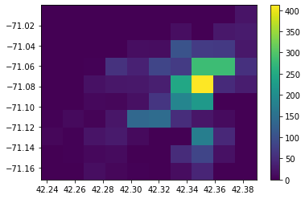

```python
#check geometrical influence
plt.hist2d(data = df_bl, x = 'latitude', y = 'longitude');
plt.colorbar();
```

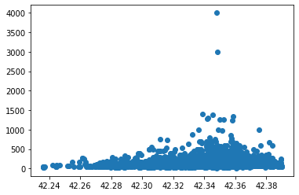

```python
plt.scatter(x = df_bl.latitude, y = df_bl.price);
```

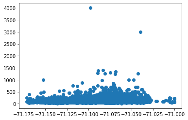

```python
plt.scatter(x = df_bl.longitude, y = df_bl.price);
```

```python
#check nan values
df_bl.describe()
```

|  | id | price | beds | bedrooms | bathrooms | accommodates | host_is_superhost | latitude | longitude |
| --- | --- | --- | --- | --- | --- | --- | --- | --- | --- |
| count | 3.585000e+03 | 3585.000000 | 3576.000000 | 3575.000000 | 3571.000000 | 3585.000000 | 3585.000000 | 3585.000000 | 3585.000000 |
| mean | 8.440875e+06 | 173.925802 | 1.609060 | 1.255944 | 1.221647 | 3.041283 | 0.113529 | 42.340032 | -71.084818 |
| std | 4.500787e+06 | 148.331321 | 1.011745 | 0.753060 | 0.501487 | 1.778929 | 0.317282 | 0.024403 | 0.031565 |
| min | 3.353000e+03 | 10.000000 | 0.000000 | 0.000000 | 0.000000 | 1.000000 | 0.000000 | 42.235942 | -71.171789 |
| 25% | 4.679319e+06 | 85.000000 | 1.000000 | 1.000000 | 1.000000 | 2.000000 | 0.000000 | 42.329995 | -71.105083 |
| 50% | 8.577620e+06 | 150.000000 | 1.000000 | 1.000000 | 1.000000 | 2.000000 | 0.000000 | 42.345201 | -71.078429 |
| 75% | 1.278953e+07 | 220.000000 | 2.000000 | 2.000000 | 1.000000 | 4.000000 | 0.000000 | 42.354685 | -71.062155 |
| max | 1.493346e+07 | 4000.000000 | 16.000000 | 5.000000 | 6.000000 | 16.000000 | 1.000000 | 42.389982 | -71.000100 |

```python
#double check if nan exist for target-variable
df_bl.price.notna().mean()
```

```
1.0
```

```python
#drop any nan-values from the predictor-variables
df_bl=df_bl.dropna()
```

```python
#check if successful
df_bl.describe()
```

|  | id | price | beds | bedrooms | bathrooms | accommodates | host_is_superhost | latitude | longitude |
| --- | --- | --- | --- | --- | --- | --- | --- | --- | --- |
| count | 3.554000e+03 | 3554.000000 | 3554.000000 | 3554.000000 | 3554.000000 | 3554.000000 | 3554.000000 | 3554.000000 | 3554.000000 |
| mean | 8.477490e+06 | 174.141531 | 1.612549 | 1.257456 | 1.222707 | 3.050366 | 0.114519 | 42.340046 | -71.084841 |
| std | 4.473766e+06 | 148.769218 | 1.013764 | 0.754651 | 0.502450 | 1.782422 | 0.318485 | 0.024451 | 0.031651 |
| min | 3.353000e+03 | 10.000000 | 0.000000 | 0.000000 | 0.000000 | 1.000000 | 0.000000 | 42.235942 | -71.171789 |
| 25% | 4.760998e+06 | 85.000000 | 1.000000 | 1.000000 | 1.000000 | 2.000000 | 0.000000 | 42.329988 | -71.105274 |
| 50% | 8.610863e+06 | 150.000000 | 1.000000 | 1.000000 | 1.000000 | 2.000000 | 0.000000 | 42.345224 | -71.078428 |
| 75% | 1.279713e+07 | 220.000000 | 2.000000 | 2.000000 | 1.000000 | 4.000000 | 0.000000 | 42.354781 | -71.062132 |
| max | 1.493346e+07 | 4000.000000 | 16.000000 | 5.000000 | 6.000000 | 16.000000 | 1.000000 | 42.389982 | -71.000100 |

```python
df_bl.room_type.value_counts()
```

```
Entire home/apt    2111
Private room       1364
Shared room        79
Name: room_type, dtype: int64
```

```python
df_bl.property_type.value_counts()
```

```
Apartment          2592
House              556
Condominium        231
Townhouse          54
Bed & Breakfast    39
Loft               39
Other              17
Boat               12
Villa              6
Entire Floor       4
Dorm               2
Guesthouse         1
Camper/RV          1
Name: property_type, dtype: int64
```

```python
#Use your newly created function
df_bl_cat = df_bl.select_dtypes(include=['object'])
cat_cols_lst = df_bl_cat.columns
df_bl = create_dummy_df(df_bl, cat_cols_lst, dummy_na=False)

#check results
df_bl.sample(5)
```

|  | id | price | beds | bedrooms | bathrooms | accommodates | host_is_superhost | latitude | longitude | property_type_Bed & Breakfast | property_type_Boat | property_type_Camper/RV | property_type_Condominium | property_type_Dorm | property_type_Entire Floor | property_type_Guesthouse | property_type_House | property_type_Loft | property_type_Other | property_type_Townhouse | property_type_Villa | room_type_Private room | room_type_Shared room |
| --- | --- | --- | --- | --- | --- | --- | --- | --- | --- | --- | --- | --- | --- | --- | --- | --- | --- | --- | --- | --- | --- | --- | --- |
| 3298 | 6476613 | 60.0 | 1.0 | 1.0 | 0.0 | 2 | 0 | 42.352445 | -71.137151 | 0 | 0 | 0 | 0 | 0 | 0 | 0 | 0 | 0 | 0 | 0 | 0 | 1 | 0 |
| 175 | 4149974 | 115.0 | 1.0 | 1.0 | 1.0 | 2 | 1 | 42.317966 | -71.111535 | 0 | 0 | 0 | 0 | 0 | 0 | 0 | 0 | 0 | 0 | 0 | 0 | 0 | 0 |
| 2626 | 7310887 | 285.0 | 4.0 | 3.0 | 1.0 | 5 | 1 | 42.345539 | -71.138190 | 0 | 0 | 0 | 0 | 0 | 0 | 0 | 0 | 0 | 0 | 0 | 0 | 0 | 0 |
| 2543 | 9256035 | 59.0 | 1.0 | 1.0 | 1.0 | 2 | 0 | 42.360958 | -71.141294 | 0 | 0 | 0 | 0 | 0 | 0 | 0 | 1 | 0 | 0 | 0 | 0 | 1 | 0 |
| 633 | 10704442 | 100.0 | 1.0 | 1.0 | 1.0 | 1 | 0 | 42.367021 | -71.054209 | 0 | 0 | 0 | 0 | 0 | 0 | 0 | 0 | 0 | 0 | 0 | 0 | 1 | 0 |

## 2 Analyse Data (Crisp-DM-Step 4 Model Data)

### 2.1 Explore - Descriptive Statistics

**b) Does the month/season influence the price of a listing?**

```python
df_bc.info();
```

```
<class 'pandas.core.frame.DataFrame'>
Int64Index: 643037 entries, 365 to 1308879
Data columns (total 5 columns):
listing_id    643037 non-null int64
date          643037 non-null object
available     643037 non-null object
price         643037 non-null float64
month         643037 non-null int64
dtypes: float64(1), int64(2), object(2)
memory usage: 29.4+ MB
```

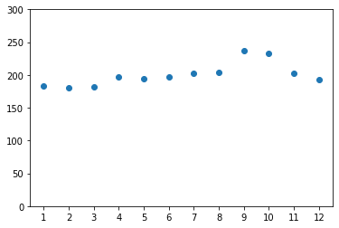

```python
plt.scatter(df_bc_agg.month, df_bc_agg.price);
plt.ylim([0, 300]);
plt.xticks(np.arange(1, 13, step=1));
```

**d) Is Boston in general more expensive than Seattle?**

```python
def calc_statistical_relevance(df, var_group_by, var_test, plot, alpha):#
    '''
    INPUT:
    df - a dataframe holding all the variables of interest
    var_group_by - a string holding the variable name to group the results by
    var_test - a string holding the variable name to calculate a confidential interval for
    print - a bool, wheter
    alpha - confidence level

    OUTPUT:
    confidential interval
    diagramm including a visualization of the confidential interval
    xwidths - mean value
    xerrs - half of confidential intervals length
    df[var_group_by].unique() - unique levels
    '''
    ############## bootstrap approach
    #build confident intervalls to double check, since hypothesis testing isn't very intuitive:
    #pro tip by udacity: The bootstrap approach with confidence intervals can be used in place of any other hypoethis test
    price_means_per_month = {}
    for level in df[var_group_by].unique():
        price_means = []
        for _ in range(100):
            #bootstrap
            bootstrap=df.loc[df[var_group_by]==level, var_test].sample(int(df.shape[0]/10), replace=True)
            #calculate sample medians
            price_mean=bootstrap.mean()
            #append to list
            price_means.append(price_mean)
        #make np.arrays
        price_means=np.array(price_means)
        price_means_per_month[level]=price_means

    xerrs=[]
    xwidths=[]
    for level in df[var_group_by].unique():
        if plot:
            print('{}: {} {}'.format(level, (round((np.percentile(price_means_per_month[level], alpha)), 2)), round((np.percentile(price_means_per_month[level], 100-alpha)), 2)))
        err=((np.percentile(price_means_per_month[level], alpha))-(np.percentile(price_means_per_month[level], 100-alpha)))/2
        xerrs.append(err)
        width=((np.percentile(price_means_per_month[level], alpha))+(np.percentile(price_means_per_month[level], 100-alpha)))/2
        xwidths.append(width)
    if plot:
        plt.figure(figsize=[10,5])
        plt.barh(width=xwidths, y=df[var_group_by].unique(), xerr=xerrs);
        plt.xlabel('mean price')
        plt.ylabel('month')
    return xwidths, xerrs, list(df[var_group_by].unique().astype(int))
```

```python
#run functions
sc_xwidths, sc_xerrs, sc_unique_levels = calc_statistical_relevance(df_sc, 'month', 'price', False, 0.0001)
bc_xwidths, bc_xerrs, bc_unique_levels = calc_statistical_relevance(df_bc, 'month', 'price', False, 0.0001)
```

[output not shown]

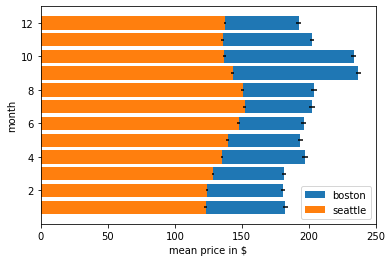

```python
#create plot data frame - pyplot
df_plot_sc = pd.DataFrame(np.array(np.transpose([sc_unique_levels, sc_xerrs, sc_xwidths])), columns = ['unique_levels', 'sc_xerrs', 'sc_xwidths'])
df_plot_bc = pd.DataFrame(np.array(np.transpose([bc_unique_levels, bc_xerrs, bc_xwidths])), columns = ['unique_levels', 'bc_xerrs', 'bc_xwidths'])
df_plot=pd.merge(df_plot_bc, df_plot_sc)
df_plot.unique_levels=df_plot.unique_levels.astype(int)

#plot
plt.barh(width=df_plot.bc_xwidths, y=df_plot.unique_levels, xerr=df_plot.bc_xerrs, label = 'boston');
plt.barh(width=df_plot.sc_xwidths, y=df_plot.unique_levels, xerr=df_plot.sc_xerrs, label = 'seattle');
plt.xlim([0, 250]);
plt.xlabel('mean price in $');
plt.ylabel('month');
plt.legend(['boston', 'seattle']);
plt.savefig('price-seattle-vs-boston-per-month.png')

#average diff
(df_plot.sc_xwidths.mean()-df_plot.bc_xwidths.mean()), (df_plot.sc_xwidths.mean()-df_plot.bc_xwidths.mean())/df_plot.sc_xwidths.mean()*100
```

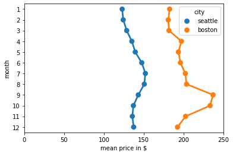

```python
#create plot data frame - pyplot
df_plot_sc = pd.DataFrame(np.array(np.transpose([sc_unique_levels, sc_xerrs, sc_xwidths])), columns = ['unique_levels', 'xerrs', 'xwidths'])
df_plot_bc = pd.DataFrame(np.array(np.transpose([bc_unique_levels, bc_xerrs, bc_xwidths])), columns = ['unique_levels', 'xerrs', 'xwidths'])
df_plot_bc['city']='boston'
df_plot_sc['city']='seattle'
df_plot=df_plot_sc.append(df_plot_bc)
df_plot.unique_levels=df_plot.unique_levels.astype(int)
sns.pointplot(y='unique_levels', x = 'xwidths', hue = 'city', orient = 'h', data=df_plot);
plt.xlim([0, 250]);
plt.xlabel('mean price in $');
plt.ylabel('month');
```

```python
#choose relevant sample by taking top_10_neighbourhoods by listing count
top_5_neighbourhoods = df_bl_neighbourhood.host_neighbourhood.value_counts().head(5).index.values
```

```
Allston-Brighton
```

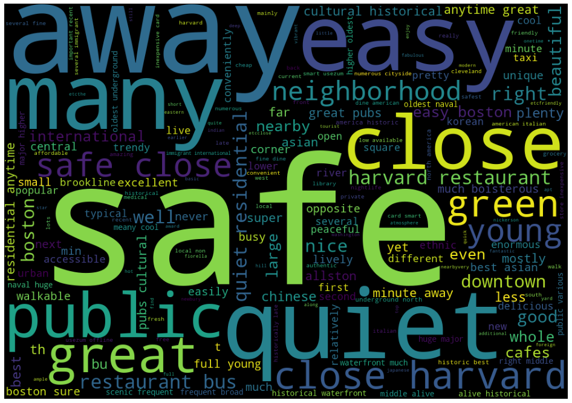

```
Fenway/Kenmore
```

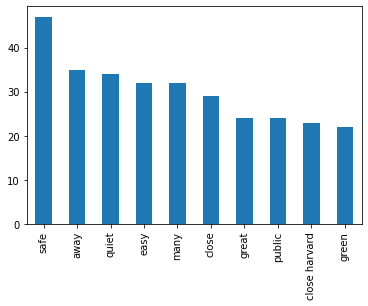

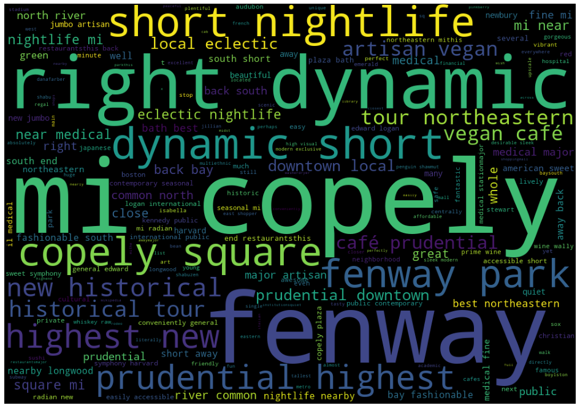

```
South End
```

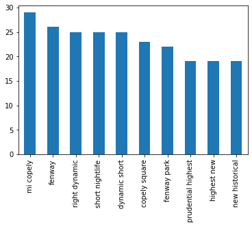

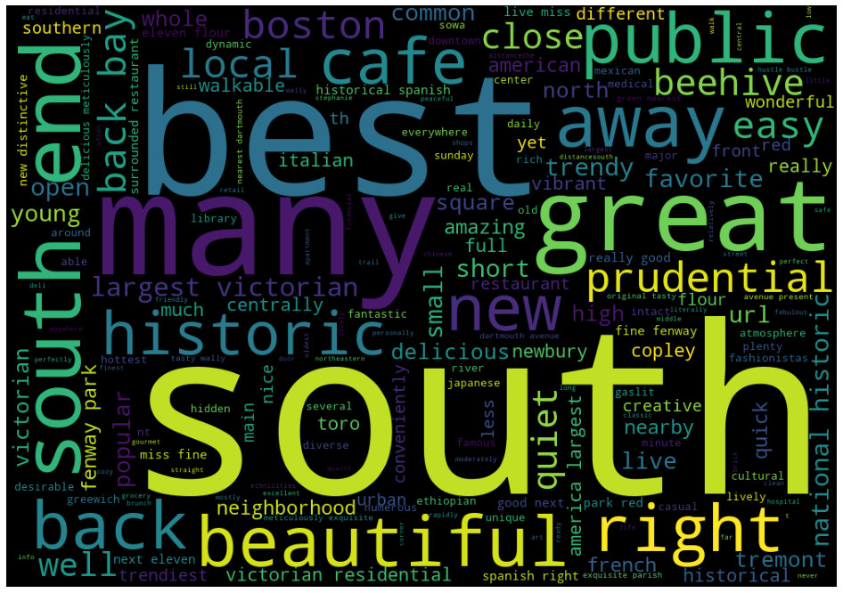

```
Beacon Hill
```

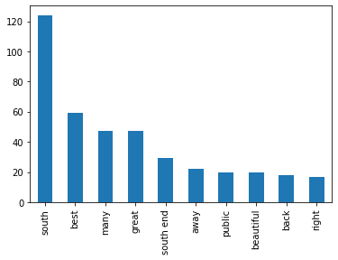

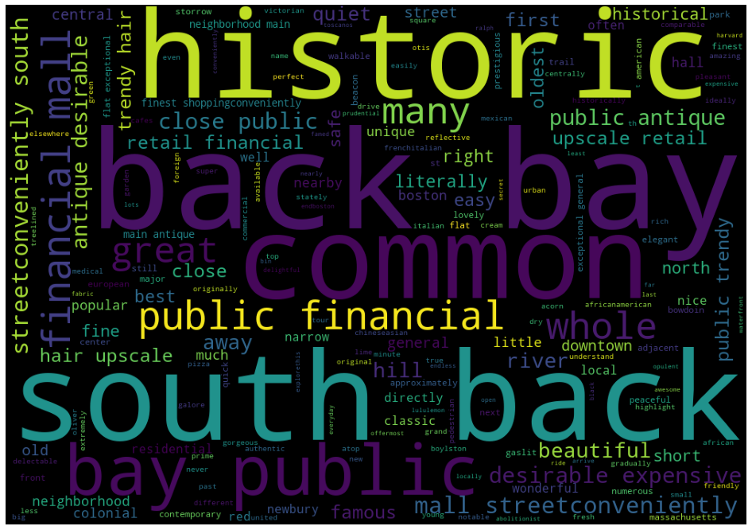

```
South Boston
```

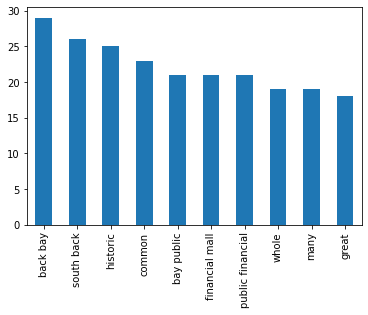

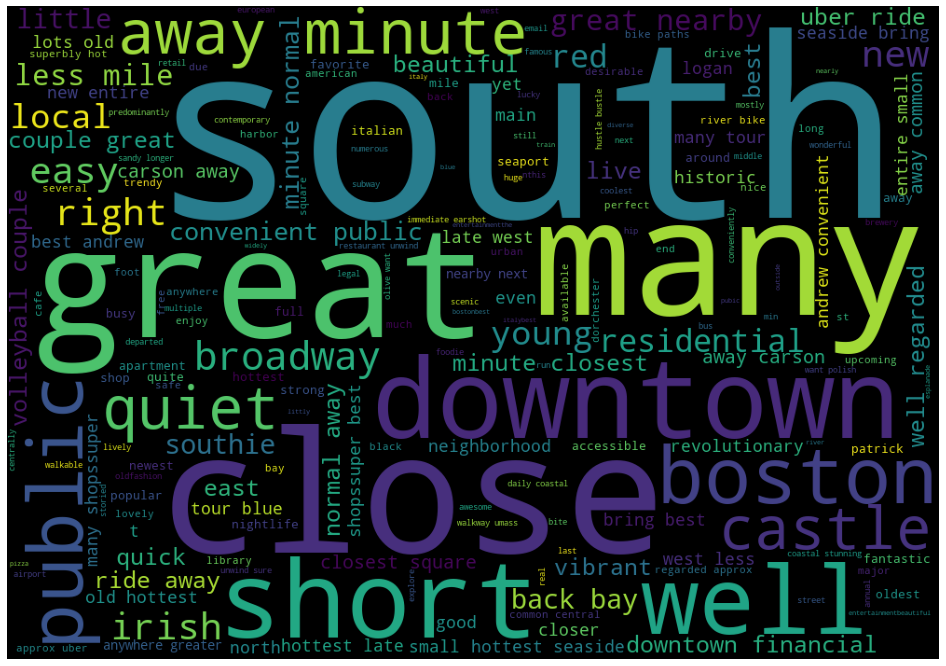

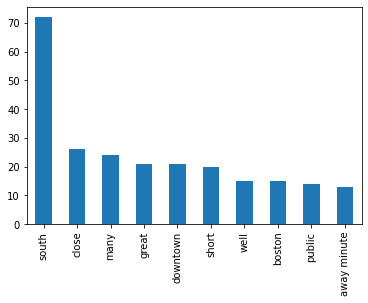

```python
#iterate through top_10_neighbourhoods and get most common words + a visualisation as a word-cloud
for hood in top_5_neighbourhoods:
    #credits/source/inspiration: https://www.kaggle.com/chaitanyakck/part-3-relationship-b-w-reviews-and-price
    #credits/source/inspiration: https://medium.com/illumination/scraping-news-and-creating-a-word-cloud-in-python-10ea312c49ba
    words=''
    for row in df_bl_neighbourhood.loc[df_bl_neighbourhood['host_neighbourhood'] == hood].iterrows():
        words += df_bl_neighbourhood.loc[df_bl_neighbourhood['host_neighbourhood'] == hood, 'neighborhood_overview'][row[0]]
    reviews_data=nltk.word_tokenize(words)
    string_punctuation = string.punctuation
    ignoreChar=['\r','\n','',' ',"'s",'!',',',]
    nums=['0','1','2','3','4','5','6','7','8','9']

    cachedStopWords = stopwords.words("english")
    cachedStopWords.append('the')

    words_only = [''.join(c for c in s if c not in string.punctuation if c not in nums if c not in ignoreChar) for s in reviews_data]
    words_only = [s for s in words_only if s]
    comments_filtered_data=' '.join(words_only)
    comments_filtered_data = ' '.join([word.lower() for word in comments_filtered_data.split() if word not in cachedStopWords])

    #only adjectives
    tokens = nltk.word_tokenize(comments_filtered_data)
    tags = nltk.pos_tag(tokens)
    comments_filtered_data_adj = [word for word, pos in tags if (pos in ['JJR', 'JJ', 'JJS', 'RB', 'RBR', 'RBS'])]
    comments_filtered_data_adj=' '.join(comments_filtered_data_adj)

    #visualize
    print(hood)
    wordcloud = WordCloud(width = 1000, height = 700).generate(comments_filtered_data_adj)
    plt.figure(figsize=(18,12))
    plt.imshow(wordcloud)
    plt.axis("off")
    plt.show()
    pd.Series(WordCloud().process_text(comments_filtered_data_adj)).sort_values(ascending=False).head(10).plot.bar()
```

```python
if 0:
    #credits/source/inspiration: https://www.kaggle.com/chaitanyakck/part-3-relationship-b-w-reviews-and-price
    words=''
    for index, row in df_br.iterrows():
        words += row['comments']

    reviews_data=nltk.word_tokenize(words)
    string_punctuation = string.punctuation
    ignoreChar=['\r','\n','',' ',"'s",'!',',',]
    nums=['0','1','2','3','4','5','6','7','8','9']

    cachedStopWords = stopwords.words("english")
    cachedStopWords.append('the')

    words_only = [''.join(c for c in s if c not in string.punctuation if c not in nums if c not in ignoreChar) for s in reviews_data]
    words_only = [s for s in words_only if s]
    comments_filtered_data=' '.join(words_only)
    comments_filtered_data = ' '.join([word.lower() for word in comments_filtered_data.split() if word not in cachedStopWords])

    wordcloud = WordCloud(width = 1000, height = 700).generate(comments_filtered_data)
    plt.figure(figsize=(18,12))
    plt.imshow(wordcloud)
    plt.axis("off")
    plt.show()
```

**a) What influences the price? Is a linear regressin model sufficient to predict the price?**

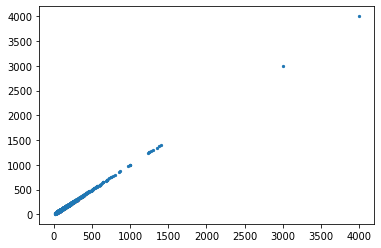

```python
plt.scatter(df_bl.price, df_bl.price, s=5);
```

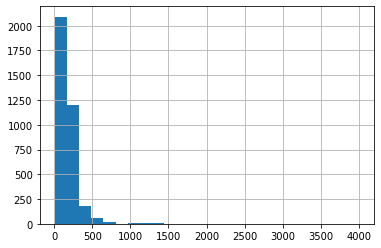

```python
#looking
df_bl.price.hist(bins=25);
```

```python
#sns.heatmap(df_bl.corr());
df_bl.corr().style.background_gradient(cmap='coolwarm')
```

|  | id | price | beds | bedrooms | bathrooms | accommodates | host_is_superhost | latitude | longitude | property_type_Bed & Breakfast | property_type_Boat | property_type_Camper/RV | property_type_Condominium | property_type_Dorm | property_type_Entire Floor | property_type_Guesthouse | property_type_House | property_type_Loft | property_type_Other | property_type_Townhouse | property_type_Villa | room_type_Private room | room_type_Shared room |
| --- | --- | --- | --- | --- | --- | --- | --- | --- | --- | --- | --- | --- | --- | --- | --- | --- | --- | --- | --- | --- | --- | --- | --- |
| id | 1 | -0.0583079 | -0.0498812 | -0.0589782 | -0.0163389 | -0.0548342 | -0.151782 | 0.0933772 | -0.0104869 | -0.0296851 | -0.0727514 | 0.0219716 | 0.0712164 | 0.017981 | 0.0230222 | 0.0235607 | -0.10135 | 0.00210368 | 0.0403739 | 0.0661873 | -0.00935188 | 0.0348904 | 0.0690706 |
| price | -0.0583079 | 1 | 0.370561 | 0.384946 | 0.24847 | 0.437505 | 0.00554458 | 0.1954 | 0.166539 | -0.0305501 | 0.0370533 | -0.0128734 | 0.0285467 | -0.0178095 | -0.0117665 | 0.0129543 | -0.121188 | 0.00797981 | 0.0260068 | -0.0209634 | 0.004246 | -0.414042 | -0.081748 |
| beds | -0.0498812 | 0.370561 | 1 | 0.710592 | 0.347096 | 0.815461 | 0.0162947 | -0.0120114 | 0.0342105 | -0.0370095 | 0.127525 | 0.0229638 | 0.0185809 | -0.0143398 | 0.0211099 | 0.00641273 | 0.0690952 | -0.0156928 | -0.0298261 | -0.0137921 | -0.0113279 | -0.351917 | -0.0609906 |
| bedrooms | -0.0589782 | 0.384946 | 0.710592 | 1 | 0.430686 | 0.725214 | 0.0306989 | -0.0459667 | 0.0160682 | -0.0323614 | 0.0444233 | -0.0279583 | 0.0325641 | -0.0080965 | 0.01079 | 0.0165097 | 0.0768384 | -0.0216229 | -0.0236551 | -0.0179941 | -0.0140314 | -0.26928 | -0.0514464 |
| bathrooms | -0.0163389 | 0.24847 | 0.347096 | 0.430686 | 1 | 0.346052 | 0.042842 | -0.0204597 | 0.0102433 | -0.0063738 | 0.0128172 | -0.0408312 | 0.000124337 | -0.0105191 | 0.00182364 | -0.0074371 | 0.19376 | -0.00906189 | 0.237147 | 0.03422 | 0.00223412 | -0.0509881 | -0.0535434 |
| accommodates | -0.0548342 | 0.437505 | 0.815461 | 0.725214 | 0.346052 | 1 | 0.0151224 | 0.053901 | 0.0844841 | -0.0484418 | 0.0908919 | 0.03718 | 0.0200878 | -0.00732792 | 0.0178864 | 0.00893942 | -0.0173858 | -0.0105543 | -0.0317069 | -0.0357774 | 0.0026836 | -0.498571 | -0.129559 |
| host_is_superhost | -0.151782 | 0.00554458 | 0.0162947 | 0.0306989 | 0.042842 | 0.0151224 | 1 | -0.0970911 | -0.035305 | 0.0554167 | -0.00570021 | -0.00603325 | -0.00521101 | -0.0085335 | -0.0120716 | -0.00603325 | 0.0859274 | 0.0130088 | 0.000681043 | 0.0347877 | 0.00673429 | 0.0577722 | 0.00571187 |
| latitude | 0.0933772 | 0.1954 | -0.0120114 | -0.0459667 | -0.0204597 | 0.053901 | -0.0970911 | 1 | 0.320592 | -0.0404241 | 0.0767623 | 0.0163584 | 0.00630642 | 0.00649979 | -0.00845884 | 0.00580768 | -0.297387 | 0.00277334 | 0.0191001 | -0.0239442 | 0.00714322 | -0.256066 | -0.0233882 |
| longitude | -0.0104869 | 0.166539 | 0.0342105 | 0.0160682 | 0.0102433 | 0.0844841 | -0.035305 | 0.320592 | 1 | -0.00274638 | 0.0725448 | 0.0142254 | 0.0583166 | -0.0144649 | -0.000850424 | 0.0082442 | -0.198432 | 0.0237295 | 0.0466489 | -0.0111638 | 0.00612631 | -0.175918 | -0.0301917 |
| property_type_Bed & Breakfast | -0.0296851 | -0.0305501 | -0.0370095 | -0.0323614 | -0.0063738 | -0.0484418 | 0.0554167 | -0.0404241 | -0.00274638 | 1 | -0.00613107 | -0.00176714 | -0.0277722 | -0.00249947 | -0.00353578 | -0.00176714 | -0.0453619 | -0.0110953 | -0.00730258 | -0.0130838 | -0.00433165 | 0.116809 | 0.00243823 |
| property_type_Boat | -0.0727514 | 0.0370533 | 0.127525 | 0.0444233 | 0.0128172 | 0.0908919 | -0.00570021 | 0.0767623 | 0.0725448 | -0.00613107 | 1 | -0.000976492 | -0.0153464 | -0.00138116 | -0.00195381 | -0.000976492 | -0.0250662 | -0.00613107 | -0.00403528 | -0.00722985 | -0.00239359 | -0.0259876 | -0.00877612 |
| property_type_Camper/RV | 0.0219716 | -0.0128734 | 0.0229638 | -0.0279583 | -0.0408312 | 0.03718 | -0.00603325 | 0.0163584 | 0.0142254 | -0.00176714 | -0.000976492 | 1 | -0.00442327 | -0.00039809 | -0.000563142 | -0.000281452 | -0.00722477 | -0.00176714 | -0.00116308 | -0.00208384 | -0.0006899 | -0.01324 | -0.00252952 |
| property_type_Condominium | 0.0712164 | 0.0285467 | 0.0185809 | 0.0325641 | 0.000124337 | 0.0200878 | -0.00521101 | 0.00630642 | 0.0583166 | -0.0277722 | -0.0153464 | -0.00442327 | 1 | -0.00625633 | -0.00885027 | -0.00442327 | -0.113544 | -0.0277722 | -0.0182788 | -0.0327494 | -0.0108424 | -0.0226632 | -0.0242696 |
| property_type_Dorm | 0.017981 | -0.0178095 | -0.0143398 | -0.0080965 | -0.0105191 | -0.00732792 | -0.0085335 | 0.00649979 | -0.0144649 | -0.00249947 | -0.00138116 | -0.00039809 | -0.00625633 | 1 | -0.000796516 | -0.00039809 | -0.0102188 | -0.00249947 | -0.00164507 | -0.00294742 | -0.000975803 | 0.0300672 | -0.00357779 |
| property_type_Entire Floor | 0.0230222 | -0.0117665 | 0.0211099 | 0.01079 | 0.00182364 | 0.0178864 | -0.0120716 | -0.00845884 | -0.000850424 | -0.00353578 | -0.00195381 | -0.000563142 | -0.00885027 | -0.000796516 | 1 | -0.000563142 | -0.0144556 | -0.00353578 | -0.00232714 | -0.00416945 | -0.00138038 | 0.00802115 | -0.00506118 |
| property_type_Guesthouse | 0.0235607 | 0.0129543 | 0.00641273 | 0.0165097 | -0.0074371 | 0.00893942 | -0.00603325 | 0.00580768 | 0.0082442 | -0.00176714 | -0.000976492 | -0.000281452 | -0.00442327 | -0.00039809 | -0.000563142 | 1 | -0.00722477 | -0.00176714 | -0.00116308 | -0.00208384 | -0.0006899 | -0.01324 | -0.00252952 |
| property_type_House | -0.10135 | -0.121188 | 0.0690952 | 0.0768384 | 0.19376 | -0.0173858 | 0.0859274 | -0.297387 | -0.198432 | -0.0453619 | -0.0250662 | -0.00722477 | -0.113544 | -0.0102188 | -0.0144556 | -0.00722477 | 1 | -0.0453619 | -0.0298558 | -0.0534915 | -0.0177095 | 0.295624 | -0.0176477 |
| property_type_Loft | 0.00210368 | 0.00797981 | -0.0156928 | -0.0216229 | -0.00906189 | -0.0105543 | 0.0130088 | 0.00277334 | 0.0237295 | -0.0110953 | -0.00613107 | -0.00176714 | -0.0277722 | -0.00249947 | -0.00353578 | -0.00176714 | -0.0453619 | 1 | -0.00730258 | -0.0130838 | -0.00433165 | -0.0386987 | 0.0207585 |
| property_type_Other | 0.0403739 | 0.0260068 | -0.0298261 | -0.0236551 | 0.237147 | -0.0317069 | 0.000681043 | 0.0191001 | 0.0466489 | -0.00730258 | -0.00403528 | -0.00116308 | -0.0182788 | -0.00164507 | -0.00232714 | -0.00116308 | -0.0298558 | -0.00730258 | 1 | -0.00861132 | -0.00285096 | 0.037531 | 0.100195 |
| property_type_Townhouse | 0.0661873 | -0.0209634 | -0.0137921 | -0.0179941 | 0.03422 | -0.0357774 | 0.0347877 | -0.0239442 | -0.0111638 | -0.0130838 | -0.00722985 | -0.00208384 | -0.0327494 | -0.00294742 | -0.00416945 | -0.00208384 | -0.0534915 | -0.0130838 | -0.00861132 | 1 | -0.00510795 | 0.0911708 | -0.0187283 |
| property_type_Villa | -0.00935188 | 0.004246 | -0.0113279 | -0.0140314 | 0.00223412 | 0.0026836 | 0.00673429 | 0.00714322 | 0.00612631 | -0.00433165 | -0.00239359 | -0.0006899 | -0.0108424 | -0.000975803 | -0.00138038 | -0.0006899 | -0.0177095 | -0.00433165 | -0.00285096 | -0.00510795 | 1 | 0.0239202 | -0.0062004 |
| room_type_Private room | 0.0348904 | -0.414042 | -0.351917 | -0.26928 | -0.0509881 | -0.498571 | 0.0577722 | -0.256066 | -0.175918 | 0.116809 | -0.0259876 | -0.01324 | -0.0226632 | 0.0300672 | 0.00802115 | -0.01324 | 0.295624 | -0.0386987 | 0.037531 | 0.0911708 | 0.0239202 | 1 | -0.118993 |
| room_type_Shared room | 0.0690706 | -0.081748 | -0.0609906 | -0.0514464 | -0.0535434 | -0.129559 | 0.00571187 | -0.0233882 | -0.0301917 | 0.00243823 | -0.00877612 | -0.00252952 | -0.0242696 | -0.00357779 | -0.00506118 | -0.00252952 | -0.0176477 | 0.0207585 | 0.100195 | -0.0187283 | -0.0062004 | -0.118993 | 1 |

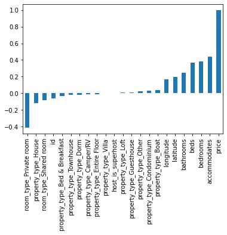

```python
#check feature importance by listing the correlation
df_bl.corr()['price'].sort_values().plot.bar();
```

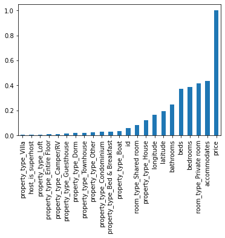

```python
#check feature importance by listing the correlation
df_bl.corr()['price'].abs().sort_values().plot.bar();
```

```python
df_bl.shape
```

```
(3554, 23)
```

```python
df_bl
```

|  | id | price | beds | bedrooms | bathrooms | accommodates | host_is_superhost | latitude | longitude | property_type_Bed & Breakfast | property_type_Boat | property_type_Camper/RV | property_type_Condominium | property_type_Dorm | property_type_Entire Floor | property_type_Guesthouse | property_type_House | property_type_Loft | property_type_Other | property_type_Townhouse | property_type_Villa | room_type_Private room | room_type_Shared room |
| --- | --- | --- | --- | --- | --- | --- | --- | --- | --- | --- | --- | --- | --- | --- | --- | --- | --- | --- | --- | --- | --- | --- | --- |
| 0 | 12147973 | 250.0 | 3.0 | 2.0 | 1.5 | 4 | 0 | 42.282619 | -71.133068 | 0 | 0 | 0 | 0 | 0 | 0 | 0 | 1 | 0 | 0 | 0 | 0 | 0 | 0 |
| 1 | 3075044 | 65.0 | 1.0 | 1.0 | 1.0 | 2 | 0 | 42.286241 | -71.134374 | 0 | 0 | 0 | 0 | 0 | 0 | 0 | 0 | 0 | 0 | 0 | 0 | 1 | 0 |
| 2 | 6976 | 65.0 | 1.0 | 1.0 | 1.0 | 2 | 1 | 42.292438 | -71.135765 | 0 | 0 | 0 | 0 | 0 | 0 | 0 | 0 | 0 | 0 | 0 | 0 | 1 | 0 |
| 3 | 1436513 | 75.0 | 2.0 | 1.0 | 1.0 | 4 | 0 | 42.281106 | -71.121021 | 0 | 0 | 0 | 0 | 0 | 0 | 0 | 1 | 0 | 0 | 0 | 0 | 1 | 0 |
| 4 | 7651065 | 79.0 | 2.0 | 1.0 | 1.5 | 2 | 1 | 42.284512 | -71.136258 | 0 | 0 | 0 | 0 | 0 | 0 | 0 | 1 | 0 | 0 | 0 | 0 | 1 | 0 |
| ... | ... | ... | ... | ... | ... | ... | ... | ... | ... | ... | ... | ... | ... | ... | ... | ... | ... | ... | ... | ... | ... | ... | ... |
| 3580 | 8373729 | 69.0 | 1.0 | 1.0 | 1.0 | 3 | 0 | 42.380968 | -71.083795 | 0 | 0 | 0 | 0 | 0 | 0 | 0 | 0 | 0 | 0 | 0 | 0 | 1 | 0 |
| 3581 | 14844274 | 150.0 | 1.0 | 1.0 | 1.0 | 2 | 0 | 42.347503 | -71.118336 | 0 | 0 | 0 | 0 | 0 | 0 | 0 | 0 | 0 | 0 | 0 | 0 | 1 | 0 |
| 3582 | 14585486 | 198.0 | 1.0 | 1.0 | 1.0 | 4 | 0 | 42.371771 | -71.071300 | 0 | 0 | 0 | 0 | 0 | 0 | 0 | 0 | 0 | 0 | 0 | 0 | 0 | 0 |
| 3583 | 14603878 | 65.0 | 1.0 | 1.0 | 1.0 | 2 | 0 | 42.385226 | -71.080923 | 0 | 0 | 0 | 0 | 0 | 0 | 0 | 0 | 0 | 0 | 0 | 0 | 1 | 0 |
| 3584 | 14504422 | 65.0 | 1.0 | 1.0 | 1.0 | 2 | 0 | 42.387888 | -71.080654 | 0 | 0 | 0 | 0 | 0 | 0 | 0 | 0 | 0 | 0 | 0 | 0 | 1 | 0 |

3554 rows × 23 columns

```python
#check feature importance by recursive feature elimination
X = df_bl.drop('price', axis=1)
y = df_bl['price']
#estimator = SVR(kernel="linear")
#estimator = LinearRegression()
#estimator = Ridge()
estimator = ElasticNet() #according to this cheat-sheet the ElasticNet-Estimator is fine: https://scikit-learn.org/stable/_static/ml_map.png
#estimator = Lasso()
#estimator = HuberRegressor() #testing the HuberRegressor which is robust to outliers
selector = RFE(estimator, n_features_to_select=10, step=5)
selector = selector.fit(X, y)
selector.support_
i=0
chosen_features=[]
for bool in selector.support_:
    if bool:
        chosen_features.append(X.columns[i])
    i+=1
chosen_features.append('price')

if 'id' in chosen_features:
    chosen_features.remove('id')
chosen_features
```

```
['beds',
 'bedrooms',
 'bathrooms',
 'accommodates',
 'latitude',
 'longitude',
 'property_type_Condominium',
 'property_type_House',
 'room_type_Private room',
 'room_type_Shared room',
 'price']
```

### 2.2 Draw Conclusions - Inferential Statistics

**a) What influences the price? Is a linear regressin model sufficient to predict the price?**

```python
#prepare dataframe
df_bl=df_bl[chosen_features]
```

```python
#only take rows, where price is less than 600. Why? a Linear regression model is not appropiate for nonlinear-data
df_bl=df_bl[df_bl.price<=600]
```

```python
df_bl
```

|  | beds | bedrooms | bathrooms | accommodates | latitude | longitude | property_type_Condominium | property_type_House | room_type_Private room | room_type_Shared room | price |
| --- | --- | --- | --- | --- | --- | --- | --- | --- | --- | --- | --- |
| 0 | 3.0 | 2.0 | 1.5 | 4 | 42.282619 | -71.133068 | 0 | 1 | 0 | 0 | 250.0 |
| 1 | 1.0 | 1.0 | 1.0 | 2 | 42.286241 | -71.134374 | 0 | 0 | 1 | 0 | 65.0 |
| 2 | 1.0 | 1.0 | 1.0 | 2 | 42.292438 | -71.135765 | 0 | 0 | 1 | 0 | 65.0 |
| 3 | 2.0 | 1.0 | 1.0 | 4 | 42.281106 | -71.121021 | 0 | 1 | 1 | 0 | 75.0 |
| 4 | 2.0 | 1.0 | 1.5 | 2 | 42.284512 | -71.136258 | 0 | 1 | 1 | 0 | 79.0 |
| ... | ... | ... | ... | ... | ... | ... | ... | ... | ... | ... | ... |
| 3580 | 1.0 | 1.0 | 1.0 | 3 | 42.380968 | -71.083795 | 0 | 0 | 1 | 0 | 69.0 |
| 3581 | 1.0 | 1.0 | 1.0 | 2 | 42.347503 | -71.118336 | 0 | 0 | 1 | 0 | 150.0 |
| 3582 | 1.0 | 1.0 | 1.0 | 4 | 42.371771 | -71.071300 | 0 | 0 | 0 | 0 | 198.0 |
| 3583 | 1.0 | 1.0 | 1.0 | 2 | 42.385226 | -71.080923 | 0 | 0 | 1 | 0 | 65.0 |
| 3584 | 1.0 | 1.0 | 1.0 | 2 | 42.387888 | -71.080654 | 0 | 0 | 1 | 0 | 65.0 |

3516 rows × 11 columns

```python
def clean_fit_linear_mod(df, response_col, cat_cols, dummy_na, test_size=.3, rand_state=42):
    '''
    INPUT:
    df - a dataframe holding all the variables of interest
    response_col - a string holding the name of the column
    cat_cols - list of strings that are associated with names of the categorical columns
    dummy_na - Bool holding whether you want to dummy NA vals of categorical columns or not
    test_size - a float between [0,1] about what proportion of data should be in the test dataset
    rand_state - an int that is provided as the random state for splitting the data into training and test

    OUTPUT:
    test_score - float - r2 score on the test data
    train_score - float - r2 score on the test data
    lm_model - model object from sklearn
    X_train, X_test, y_train, y_test - output from sklearn train test split used for optimal model

    Your function should:
    1. Drop the rows with missing response values
    2. Drop columns with NaN for all the values
    3. Use create_dummy_df to dummy categorical columns
    4. Fill the mean of the column for any missing values
    5. Split your data into an X matrix and a response vector y
    6. Create training and test sets of data
    7. Instantiate a LinearRegression model with normalized data
    8. Fit your model to the training data
    9. Predict the response for the training data and the test data
    10. Obtain an rsquared value for both the training and test data
    '''
    #Drop the rows with missing response values
    df  = df.dropna(subset=[response_col], axis=0)


    #Drop columns with all NaN values
    df = df.dropna(how='all', axis=1)

    #Dummy categorical variables
    df = create_dummy_df(df, cat_cols, dummy_na)

    # Mean function
    fill_mean = lambda col: col.fillna(col.mean())
    # Fill the mean
    df = df.apply(fill_mean, axis=0)

    #Split into explanatory and response variables
    X = df.drop(response_col, axis=1)
    y = df[response_col]

    #Split into train and test
    X_train, X_test, y_train, y_test = train_test_split(X, y, test_size=test_size, random_state=rand_state)

    lm_model = LinearRegression(normalize=True) # Instantiate
    lm_model.fit(X_train, y_train) #Fit

    #Predict using your model
    y_test_preds = lm_model.predict(X_test)
    y_train_preds = lm_model.predict(X_train)

    #Score using your model
    test_score = r2_score(y_test, y_test_preds)
    train_score = r2_score(y_train, y_train_preds)

    #create resulting data-frame
    df_result = pd.DataFrame(np.transpose([list(np.transpose(np.linspace(1, len(list(lm_model.coef_)), len(list(lm_model.coef_))))), list(X_test.columns), list(lm_model.coef_)]), columns=['idx', 'coeff_idx', 'coeff_val' ])
    df_result.coeff_val=df_result.coeff_val.astype(float)
    df_result=df_result.append(pd.DataFrame([[10, 'intercept', lm_model.intercept_]], columns =['idx', 'coeff_idx', 'coeff_val']))

    return test_score, train_score, lm_model, X_train, X_test, y_train, y_test, y_test_preds, df_result

#Test your function with the above dataset
test_score, train_score, lm_model, X_train, X_test, y_train, y_test, y_test_preds, df_result = clean_fit_linear_mod(df_bl, 'price', cat_cols_lst, dummy_na=False)
```

```python
#r-squared for predicting the price
test_score
```

```
0.5072070730055049
```

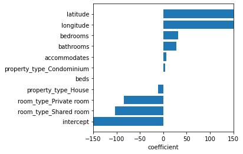

```python
plt.figure(figsize=[6, 4])
plt.barh(y=df_result.sort_values(by = 'coeff_val').coeff_idx, width=df_result.sort_values(by = 'coeff_val').coeff_val);
plt.xlabel('coefficient');
plt.gcf().subplots_adjust(left=0.35)
plt.xlim([-150, 150])
plt.savefig('regression-coefficients.png')
```

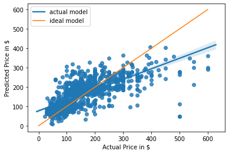

```python
#predicted vs. actual price
sns.regplot(y_test, y_test_preds);
plt.plot([0, 600], [0, 600])
plt.xlabel('Actual Price in $')
plt.ylabel('Predicted Price in $');
plt.legend(['actual model', 'ideal model']);
plt.savefig('actual-vs-predicted-price.png')
```

### 2.3 Communicate the results (Crisp-DM-Step 5 Results)

https://medium.com/p/9ff6790db48e/